# Tópicos em Econometria Regressão Linear

Encontro 7 | 17/09/20024  
Henrique Costa | Métodos Estratégicos em FinQuant

# A natureza da análise de regressão

## Origem histórica do termo regressão

- O termo regressão foi criado por Francis Galton
  - Em um artigo famoso, Galton verificou que, a variação na altura tendia a mover-se ou “regredir” à altura média da população como um todo.
  - A lei da regressão universal de Galton foi confirmada por seu amigo Karl Pearson
- Nas palavras de Galton, isso era uma “regressão à mediocridade”

$$\beta > \frac{1}{n} \sum^{n}_{i=1} x_{i}$$

- Em que:
  - $\beta$ = Be
  - $>$ = Greate than
  - $\sum^{n}_{i=1} x_{i}$ = Average
- Seja melhor que a média

## Conceito de função de regressão

- Função de regressão populacional (FRP)
  - $E(Y|X_{i}) = f(X_{i})$
  - $E(Y|X_{i}) = \beta_{1} + \beta_{2} X_{i}$
- Especificação estocástica da FRP
  - $u_{i} = Y_{i} - E(Y|X_{i})$
  - $Y_{i} = E(Y|X_{i}) + u_{i}$
  - $$Y_{i} = \beta_{1} + \beta_{2} X_{i} + u_{i}$$
- Função de regressão amostral (FRA)
  - $\hat{Y_{i}} = \hat{\beta_{1}} + \hat{\beta_{2}} X_{i}$
  - $$\hat{Y_{i}} = \hat{\beta_{1}} + \hat{\beta_{2}} X_{i} + \hat{u_{i}}$$

## Exemplo

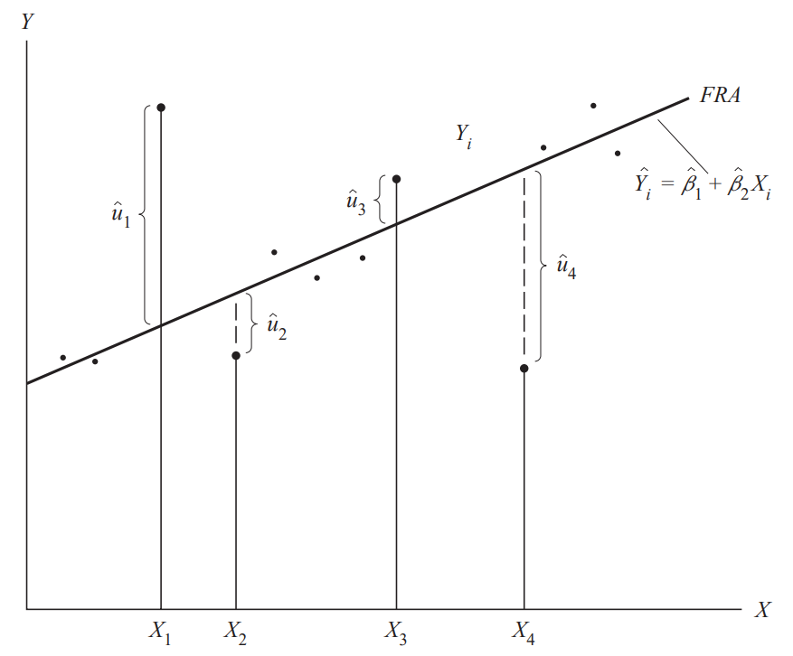

# A estimação

## Mínimos quadrados ordinários

- Este método é atribuído a Carl Friedrich Gauss
  - Sob certas hipóteses, o MQO tem algumas propriedades estatísticas muito atraentes que o tornou um dos métodos de análise de regressão mais poderosos e difundidos.
- A FRP não pode ser observada diretamente, por isso temos quee estimá-la por meio da FRA.
- Mas como determinamos a FRA propriamente dita?
- $\hat{u_{i}} = Y_{i} - \hat{Y_{i}}$
- $\hat{u_{i}} = Y_{i} - \hat{\beta_{1}} - \hat{\beta_{2}} X_{i}$
- O método que mínimiza $\hat{u_{i}}$.
  - $\sum\hat{u_{i}}^2 = \sum(Y_{i} - \hat{Y_{i}})^2$
  - $\sum\hat{u_{i}}^2 = \sum(Y_{i} - \hat{\beta_{1}} - \hat{\beta_{2}} X_{i})^2$
- $$\sum\hat{u_{i}}^2 = f(\alpha, \beta) = min_{\alpha, \beta} \sum^{n}_{i=1} (Y_{i} - \alpha - \beta X_{i})^2$$

## $$min_{\alpha, \beta} \bar{\hat{u_{i}}} = 0$$

- Isto pode ser verificável quando:
  - $\bar{\hat{Y}} = \bar{Y}$ .
- Pelo fato de que $\sum (X_{i} - \bar{X}) = 0$.

## Exemplo

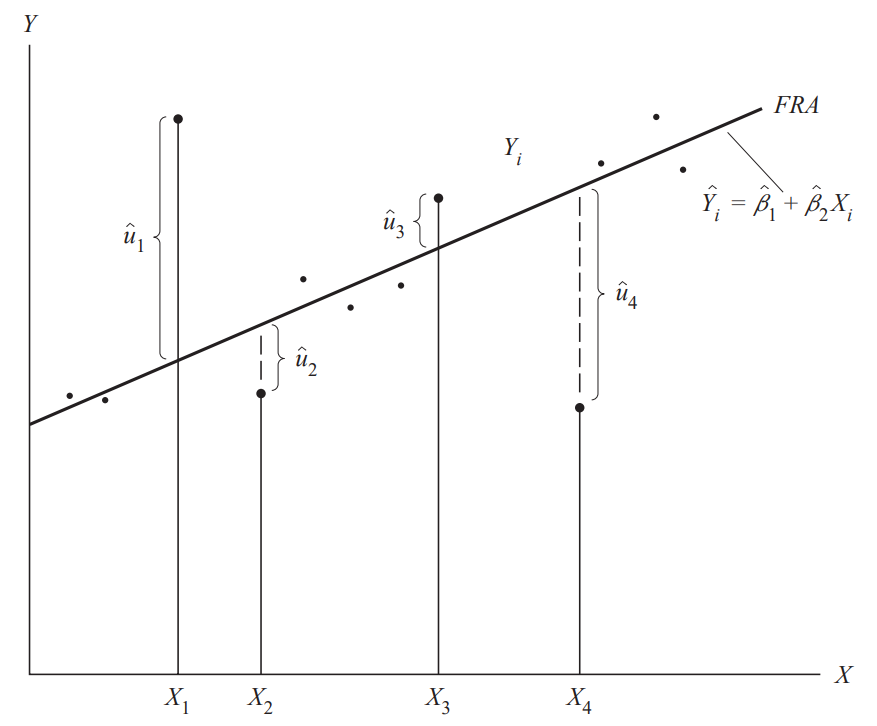

# As hipóteses básicas do método dos mínimos quadrados

## Hipóteses teóricas:

- **Hipótese 1**: Modelo de regressão linear
  - o modelo de regressão é linear nos parâmetros.
- **Hipótese 2**: X fixo ou independente do termo de erro
  - supõe-se que as variáveis X e o termo de erro são independentes, isto é, $cov(X_{i}, u_{i})=0$.

## Hipóteses teóricas:

- **Hipótese 3**: a média do termo de erro $\bar{u_{i}} = 0$ (é zero)
  - fatores não incluídos explicitamente no modelo e, portanto, agrupados em $u_{i}$, não afetam sistematicamente o valor médio de $Y$
  - valores positivos de $u_{i}$ cancelam os negativos, de modo que seu efeito médio sobre $Y$ é igual a 0 (zero).

## **Hipótese 4**: Homocedasticidade

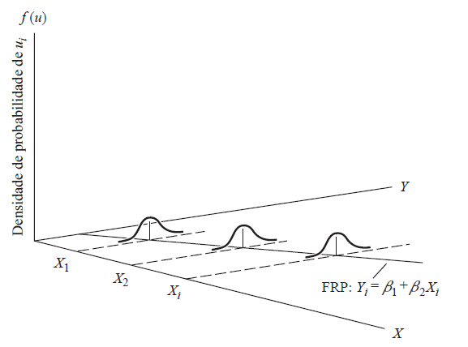

## **Hipótese 4**: Heterocedasticidade

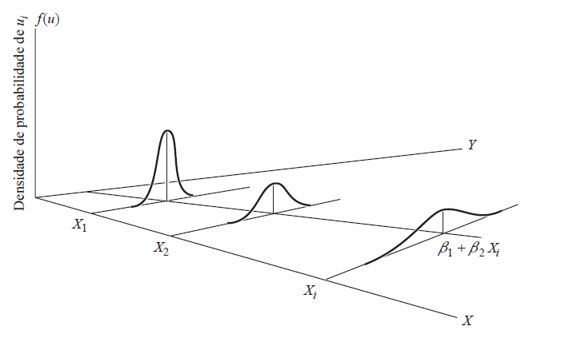

## Hipóteses teóricas:

- **Hipótese 5**: ausencia de autocorrelação entre os termos de erro
  - dados quaisquer dois valores de $X$, $X_{i}$, $X_{j}$ ($i \neq j$), a correlação entre quaisquer dois $u_{i}$, $u_{j}$ ($i \neq j$) é zero.
  - os termos de erro $u_{i}$ e $u_{j}$ não são correlacionados. Tecnicamente, esta é a hipótese de ausência de correlação serial ou de ausência de autocorrelação.

## **Hipótese 5**: ausencia de correlação serial (autocorrelação)

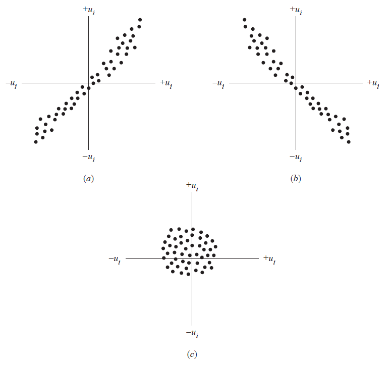

## Hipóteses teóricas:

- **Hipótese 6**: O número de observações $n$ deve ser maior que o número de parâmetros a serem estimados.
- **Hipótese 7**: Variabilidade dos valores de $X$
  - os valores de X em uma amostra não devem ser os mesmos.
  - $var (X)$ deve ser um número positivo.
  - não pode haver valores extremos (*outliers*) da variável $X$.

## A hipótese de normalidade de $u_{i}$:

- Supõe que cada $u_{i}$ seja distribuído *normalmente*.
  - Média: $E(u_{i}) = 0$
  - Variância: $E[u_{i} - E(u_{i})]^{2} = E(u^{2}_{i}) = \sigma^{2}$
  - $cov(u_{i}, u_{j})$: $E\{[(u_{i} - E(u_{i})][u_{j} - E(u_{j})]\} = E(u_{i} \; u_{j} ) = 0 \;\;\;\; i \neq j$
- Isso pode ser representado de forma mais compacta:
  - $u_{i} \; \sim \; N(0, \sigma^{2})$
  - Erros distribuídos normalmente com média zero e variância constante.

# Diagnóstico

## Diagnóstico: analisando o resultado.

- O que devemos analisar no resultado de uma regressão linear?
  - $u_{i} \; \sim \; N(0, \sigma^{2})$
  - Erro padrão (Std. Error)
  - *P-valor* - Teste de Hipótese *t*-student
  - *P-valor* - Teste de Hipótese *F* ($F-statistic > 5.32$)
  - $R^{2}$ - Coeficiênte de Determinação
- O pacote `performance` pode facilitar nossas vidas

# [Prática](https://hcostax.netlify.app/blog/regression/)